# Smouldering and flaming fire in upland swamp soils

```r
library(ggplot2)
library(dplyr)
library(DHARMa)
library(emmeans)
library(parameters)
library(table1)
library(MuMIn)
```

### Data

```r
datadir <- "../data"
flaming <- read.csv(file.path(datadir,"Sod_Data_flaming_moist_som_main.csv"))
```

```r
burn_data <- flaming %>%
  filter(!Sample=='MH CH 19') %>% # remove outlier
  mutate(binomial_burn_status = binomial_iCone_burn_status,
         grav_moist_percent = grav_moist_percent_dec2023,
         som_percent = som_percent_Jan24,
         bd_mg_per_cm3 = bd_g_per_cm3_May23,
         Fire_treat = factor(Fire_treat, levels = c("Low", "High")))

table1(~grav_moist_percent+bd_mg_per_cm3+som_percent|Fire_treat+binomial_burn_status,data=burn_data)
```

|  | Low 0 (N=39) | Low 1 (N=18) | High 0 (N=36) | High 1 (N=18) | Overall 0 (N=75) | Overall 1 (N=36) |
| --- | --- | --- | --- | --- | --- | --- |
| grav_moist_percent |  |  |  |  |  |  |
| Mean (SD) | 227 (169) | 19.7 (8.71) | 230 (140) | 31.9 (40.9) | 228 (155) | 25.8 (29.8) |
| Median [Min, Max] | 203 [5.52, 718] | 18.9 [8.68, 39.7] | 203 [27.6, 450] | 23.6 [9.06, 193] | 203 [5.52, 718] | 19.8 [8.68, 193] |
| bd_mg_per_cm3 |  |  |  |  |  |  |
| Mean (SD) | 0.320 (0.206) | 0.303 (0.129) | 0.315 (0.178) | 0.339 (0.192) | 0.318 (0.192) | 0.321 (0.162) |
| Median [Min, Max] | 0.251 [0.129, 1.25] | 0.253 [0.142, 0.514] | 0.243 [0.109, 0.807] | 0.289 [0.123, 0.820] | 0.247 [0.109, 1.25] | 0.280 [0.123, 0.820] |
| som_percent |  |  |  |  |  |  |
| Mean (SD) | 40.6 (23.2) | 44.5 (19.5) | 36.4 (20.8) | 45.3 (24.4) | 38.6 (22.0) | 44.9 (21.8) |
| Median [Min, Max] | 38.7 [7.52, 97.4] | 43.2 [8.63, 84.4] | 33.2 [4.54, 79.1] | 40.3 [13.9, 90.2] | 37.4 [4.54, 97.4] | 43.2 [8.63, 90.2] |

## Flaming fire analysis - BAL40

```r
som_gravmoist <- burn_data %>%
  filter(Fire_treat == "Low")
```

### Explore

Plot against burning status.

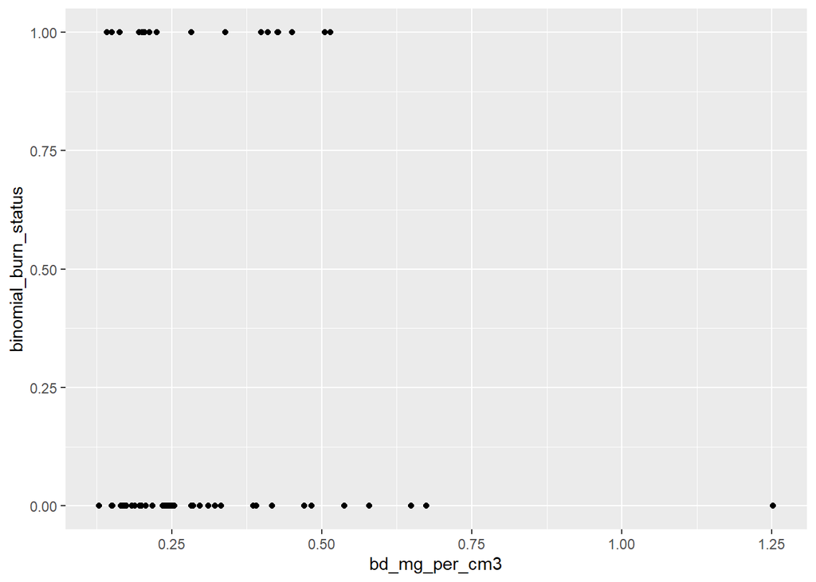

```r
ggplot(som_gravmoist, aes(bd_mg_per_cm3, binomial_burn_status))+
  geom_point()
```

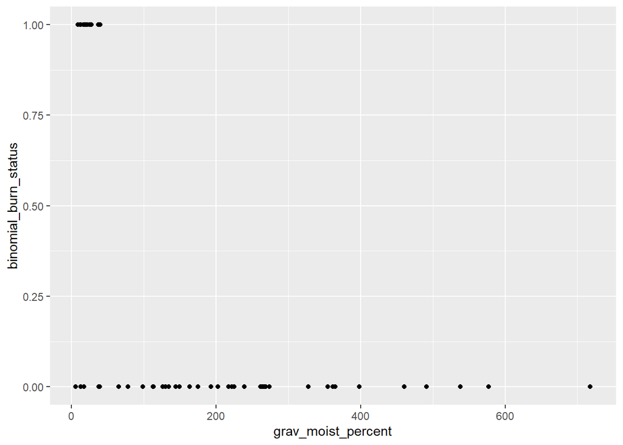

```r
ggplot(som_gravmoist, aes(grav_moist_percent, binomial_burn_status))+
  geom_point()
```

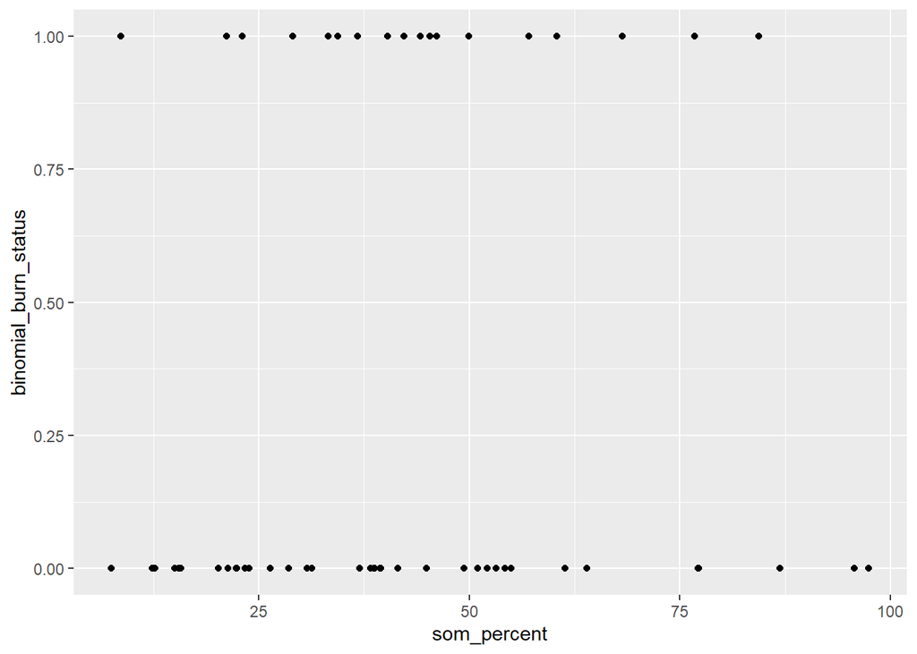

```r
ggplot(som_gravmoist, aes(som_percent, binomial_burn_status))+
  geom_point()
```

We expect grav_moist_percent will be strongest predictor.

### Model

Due to small sample size, we will include only one variable in model to predict burning. Use AICc to choose variable.

```r
base_mod_smould <- glm(binomial_burn_status ~1, family=binomial, data = som_gravmoist)
base_mod_smould_grav <- glm(binomial_burn_status ~  + grav_moist_percent, family=binomial, data = som_gravmoist)
base_mod_smould_som <- glm(binomial_burn_status ~  +som_percent, family=binomial, data = som_gravmoist)
base_mod_smould_bd <- glm(binomial_burn_status ~  + bd_mg_per_cm3, family=binomial, data = som_gravmoist)

AICc(base_mod_smould, base_mod_smould_grav, base_mod_smould_som, base_mod_smould_bd)
```

|  | df | AICc |
| --- | --- | --- |
| base_mod_smould | 1 | 73.16938 |
| base_mod_smould_grav | 2 | 32.95342 |
| base_mod_smould_som | 2 | 74.93229 |
| base_mod_smould_bd | 2 | 75.20355 |

grav is by far the best predictor

```r
BAL40_mod <- base_mod_smould_grav
```

Check assumptions

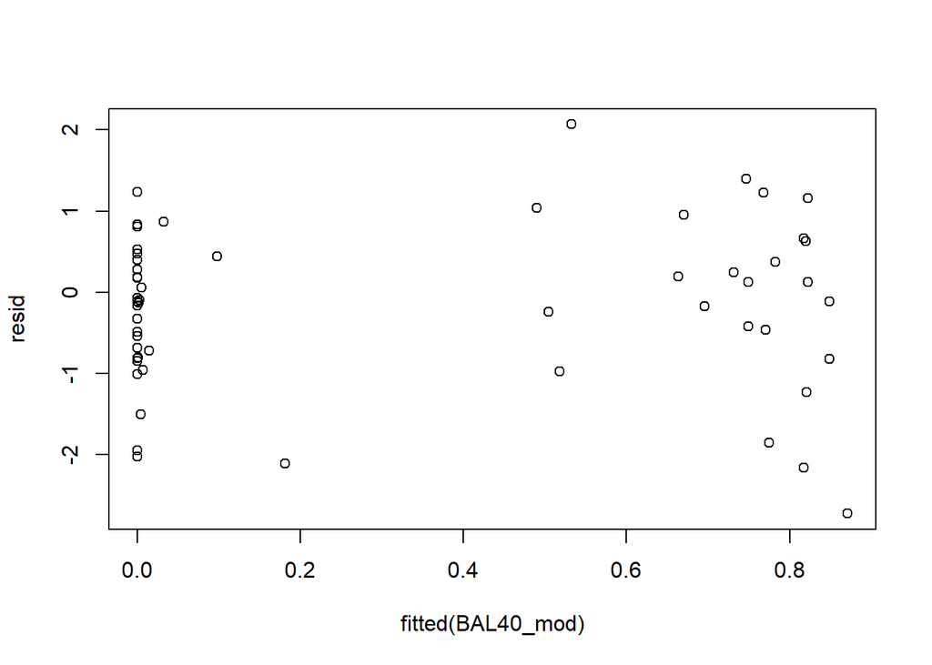

```r
sim= simulateResiduals(BAL40_mod)
resid = residuals(sim, quantileFunction = qnorm, outlierValues = c(-7,7))
plot(resid~fitted(BAL40_mod))
```

Residuals are okay.

The model has warnings about ‘fitted probabilities numerically 0 or 1 occurred’, this is often perfect separation. We look at standard errors of coefficients.

```r
summary(BAL40_mod)
```

```
##
## Call:
## glm(formula = binomial_burn_status ~ +grav_moist_percent, family = binomial,
##     data = som_gravmoist)
##
## Coefficients:
##                    Estimate Std. Error z value Pr(>|z|)
## (Intercept)         2.22397    0.79373   2.802  0.00508 **
## grav_moist_percent -0.05704    0.02468  -2.311  0.02081 *
## ---
## Signif. codes:  0 '***' 0.001 '**' 0.01 '*' 0.05 '.' 0.1 ' ' 1
##
## (Dispersion parameter for binomial family taken to be 1)
##
##     Null deviance: 71.097  on 56  degrees of freedom
## Residual deviance: 28.731  on 55  degrees of freedom
## AIC: 32.731
##
## Number of Fisher Scoring iterations: 9
```

Standard errors are reasonable. For large values of grav, the probability of burning is appropriately very near 0 (see plots below), so we don’t believe there is perfect separation.

### Inference

Calculate odds ratios.

```r
parameters(BAL40_mod, exponentiate = T, ci_method  = "profile", digits = 4)
```

| Parameter | Coefficient | SE | CI | CI_low | CI_high | z | df_error | p |
| --- | --- | --- | --- | --- | --- | --- | --- | --- |
| (Intercept) | 9.2439147 | 7.33714793 | 0.95 | 2.4480122 | 62.4155415 | 2.801926 | Inf | 0.005079849 |
| grav_moist_percent | 0.9445576 | 0.02330887 | 0.95 | 0.8832901 | 0.9760485 | -2.311408 | Inf | 0.020810342 |

Calculate predictions

```r
ems_BAL40 = emmip(BAL40_mod, ~ grav_moist_percent, type = "response",  CIs = TRUE,
      at = list(grav_moist_percent = seq(0,500,by=5)), plotit = FALSE)

write.csv(ems_BAL40,file="../results/prob_BAL40.csv")

ems_BAL40 %>%
  filter(grav_moist_percent %in% c(50, 100, 150)) %>%
  transmute(grav_moist_percent,
            pred_burn_prob = round(yvar, 4),
            LCL = round(LCL, 4),
            UCL = round(UCL,4))
```

| grav_moist_percent | pred_burn_prob | LCL | UCL |
| --- | --- | --- | --- |
| 50 | 0.3480 | 0.1097 | 0.6980 |
| 100 | 0.0299 | 0.0008 | 0.5509 |
| 150 | 0.0018 | 0.0000 | 0.4319 |

Plot.

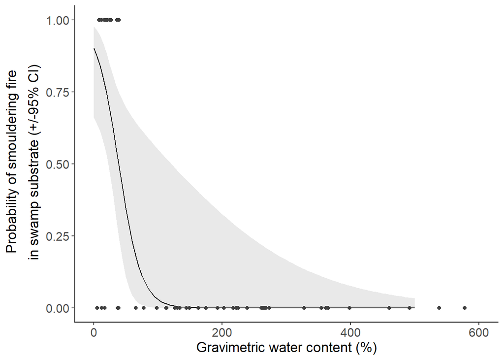

```r
BAL40_plot <- ggplot(ems_BAL40, aes(grav_moist_percent, yvar)) +
  geom_ribbon(aes(ymin = LCL, ymax = UCL), alpha = 0.5, fill = "lightgrey")+
  geom_line()+
  geom_point(colour = "grey25", data = som_gravmoist, aes(grav_moist_percent,binomial_burn_status)) +
  xlab("Gravimetric water content (%)")+
  ylab(expression(atop(paste("Probability of smouldering fire"), paste("in swamp substrate (+/-95% CI)"))))+
  theme(axis.text = element_text(size = 12))+
  theme(axis.title = element_text(size = 14), strip.background = element_rect(colour="white", fill="white"))+
  theme(plot.title = element_text(size = 14))+
  theme(strip.text = element_text(size = 14))+
  theme(legend.text = element_text(size = 12))+
  xlim(0,600)+
    theme(panel.grid.major = element_blank(), panel.grid.minor = element_blank(),
        panel.background = element_blank(), axis.line = element_line(colour = "black"))
BAL40_plot
```

```r
ggsave(plot = BAL40_plot, file = "../results/BAL40_plot.tiff" , width = 180, height = 150, units = "mm", device = "tiff")
```

## Flaming fire analysis - BALFZ

```r
som_gravmoist <- burn_data %>%
  filter(Fire_treat == "High")
```

### Explore

Plot against burning status.

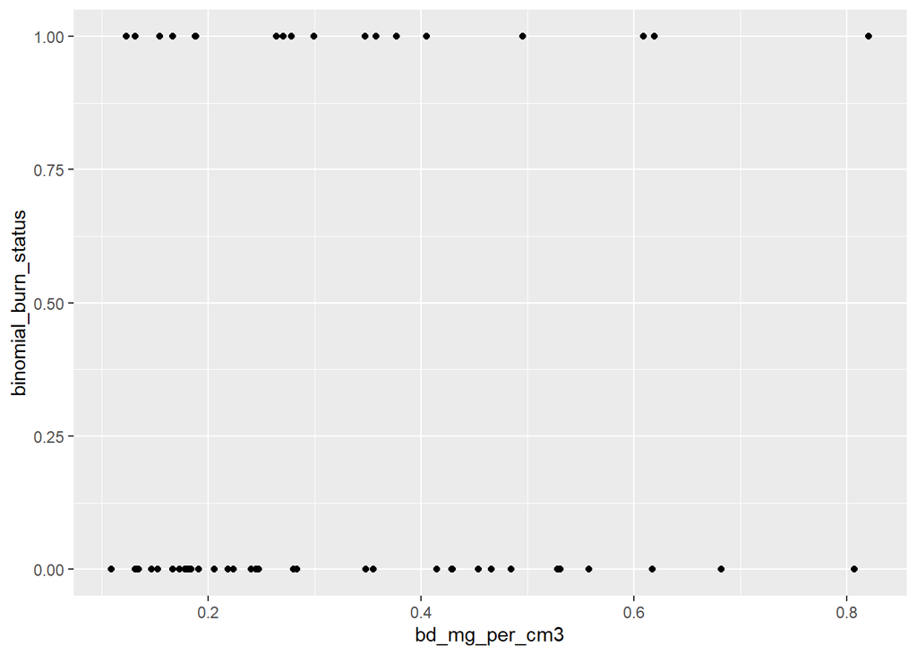

```r
ggplot(som_gravmoist, aes(bd_mg_per_cm3, binomial_burn_status))+
  geom_point()
```

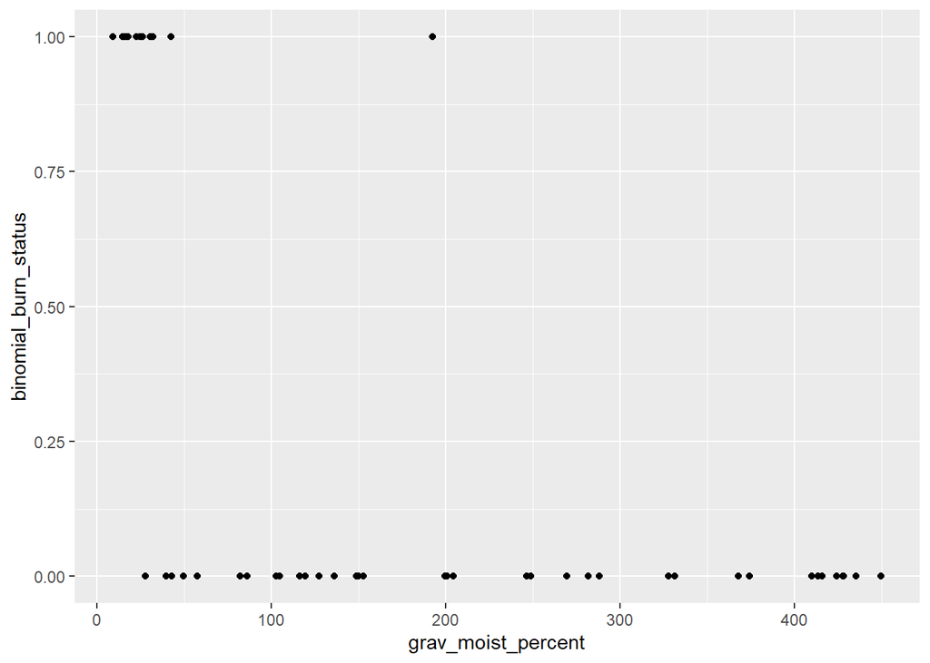

```r
ggplot(som_gravmoist, aes(grav_moist_percent, binomial_burn_status))+
  geom_point()
```

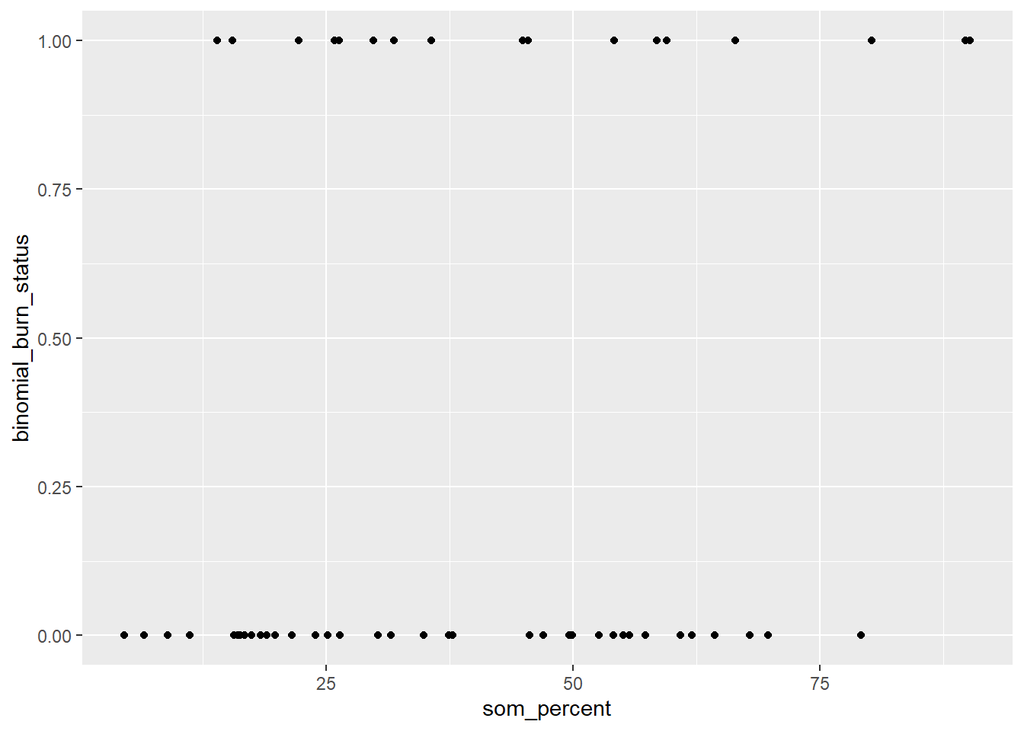

```r
ggplot(som_gravmoist, aes(som_percent, binomial_burn_status))+
  geom_point()
```

We expect grav_moist_percent will be strongest predictor.

### Model

Due to small sample size, we will include only one variable in model to predict burning. Use AICc to choose variable.

```r
base_mod_smould <- glm(binomial_burn_status ~1, family=binomial, data = som_gravmoist)
base_mod_smould_grav <- glm(binomial_burn_status ~  + grav_moist_percent, family=binomial, data = som_gravmoist)
base_mod_smould_som <- glm(binomial_burn_status ~  +som_percent, family=binomial, data = som_gravmoist)
base_mod_smould_bd <- glm(binomial_burn_status ~  + bd_mg_per_cm3, family=binomial, data = som_gravmoist)

AICc(base_mod_smould, base_mod_smould_grav, base_mod_smould_som, base_mod_smould_bd)
```

|  | df | AICc |
| --- | --- | --- |
| base_mod_smould | 1 | 70.82045 |
| base_mod_smould_grav | 2 | 35.59101 |
| base_mod_smould_som | 2 | 71.00542 |
| base_mod_smould_bd | 2 | 72.77077 |

grav is by far the best predictor

```r
BALFZ_mod <- base_mod_smould_grav
```

Check assumptions

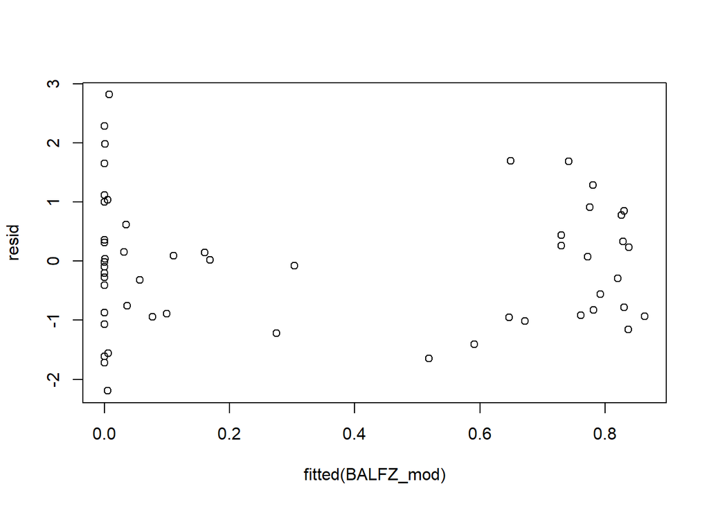

```r
sim= simulateResiduals(BALFZ_mod)
resid = residuals(sim, quantileFunction = qnorm, outlierValues = c(-7,7))
plot(resid~fitted(BALFZ_mod))
```

Residuals are okay.

### Inference

Calculate odds ratios.

```r
parameters(BALFZ_mod, exponentiate = T, ci_method  = "profile", digits = 4)
```

| Parameter | Coefficient | SE | CI | CI_low | CI_high | z | df_error | p |
| --- | --- | --- | --- | --- | --- | --- | --- | --- |
| (Intercept) | 8.7985943 | 6.39890254 | 0.95 | 2.4346425 | 44.6915023 | 2.990099 | Inf | 0.002788870 |
| grav_moist_percent | 0.9640098 | 0.01168233 | 0.95 | 0.9352809 | 0.9823394 | -3.024621 | Inf | 0.002489452 |

Calculate predictions

```r
ems_BALFZ = emmip(BALFZ_mod, ~ grav_moist_percent, type = "response",  CIs = TRUE,
      at = list(grav_moist_percent = seq(0,500,by=5)), plotit = FALSE)

write.csv(ems_BALFZ,file="../results/prob_BALFZ.csv")

ems_BALFZ %>%
  filter(grav_moist_percent %in% c(50, 100, 150)) %>%
  transmute(grav_moist_percent,
            pred_burn_prob = round(yvar, 4),
            LCL = round(LCL, 4),
            UCL = round(UCL,4))
```

| grav_moist_percent | pred_burn_prob | LCL | UCL |
| --- | --- | --- | --- |
| 50 | 0.5847 | 0.3693 | 0.7719 |
| 100 | 0.1838 | 0.0467 | 0.5087 |
| 150 | 0.0348 | 0.0027 | 0.3243 |

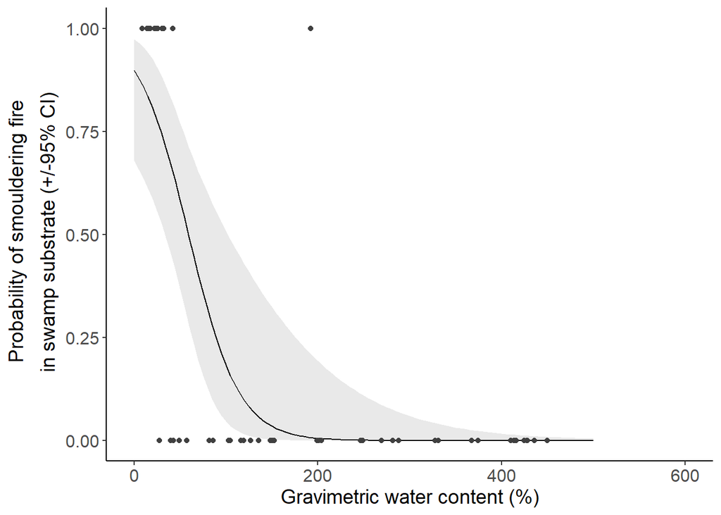

```r
BALFZ_plot <- ggplot(ems_BALFZ, aes(grav_moist_percent, yvar)) +
  geom_ribbon(aes(ymin = LCL, ymax = UCL), alpha = 0.5, fill = "lightgrey")+
  geom_line()+
  geom_point(colour = "grey25", data = som_gravmoist, aes(grav_moist_percent,binomial_burn_status)) +
  xlab("Gravimetric water content (%)")+
  ylab(expression(atop(paste("Probability of smouldering fire"), paste("in swamp substrate (+/-95% CI)"))))+
  theme(axis.text = element_text(size = 12))+
  theme(axis.title = element_text(size = 14), strip.background = element_rect(colour="white", fill="white"))+
  theme(plot.title = element_text(size = 14))+
  theme(strip.text = element_text(size = 14))+
  theme(legend.text = element_text(size = 12))+
  xlim(0,600)+
    theme(panel.grid.major = element_blank(), panel.grid.minor = element_blank(),
        panel.background = element_blank(), axis.line = element_line(colour = "black"))
BALFZ_plot
```

```r
ggsave(plot = BALFZ_plot, file = "../results/BALFZ_plot.tiff" , width = 180, height = 150, units = "mm", device = "tiff")
```

Does temperature affect probability of burning?

### Model

Fit model and check assumptions

```r
flaming_mod <- glm(binomial_burn_status ~ grav_moist_percent + som_percent + bd_mg_per_cm3 + Fire_treat, family=binomial, data = burn_data)
```

```
## Warning: glm.fit: fitted probabilities numerically 0 or 1 occurred
```

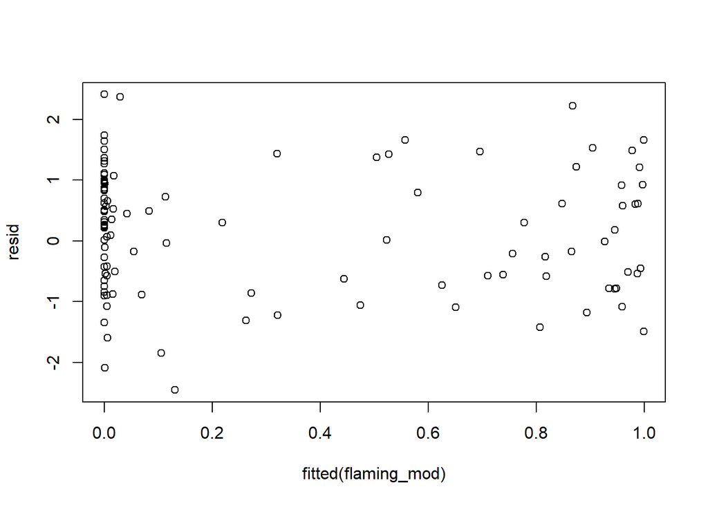

```r
sim= simulateResiduals(flaming_mod)
resid = residuals(sim, quantileFunction = qnorm, outlierValues = c(-7,7))
plot(resid~fitted(flaming_mod))
```

Residuals are okay.

The model has warnings about ‘fitted probabilities numerically 0 or 1 occurred’, this is often perfect separation. We look at standard errors of coefficients.

```r
summary(flaming_mod)
```

```
##
## Call:
## glm(formula = binomial_burn_status ~ grav_moist_percent + som_percent +
##     bd_mg_per_cm3 + Fire_treat, family = binomial, data = burn_data)
##
## Coefficients:
##                    Estimate Std. Error z value Pr(>|z|)
## (Intercept)         0.97576    1.71451   0.569  0.56928
## grav_moist_percent -0.05297    0.01438  -3.684  0.00023 ***
## som_percent         0.06174    0.02855   2.163  0.03055 *
## bd_mg_per_cm3      -3.13971    2.62631  -1.195  0.23190
## Fire_treatHigh      1.99726    1.01638   1.965  0.04940 *
## ---
## Signif. codes:  0 '***' 0.001 '**' 0.01 '*' 0.05 '.' 0.1 ' ' 1
##
## (Dispersion parameter for binomial family taken to be 1)
##
##     Null deviance: 139.879  on 110  degrees of freedom
## Residual deviance:  42.323  on 106  degrees of freedom
## AIC: 52.323
##
## Number of Fisher Scoring iterations: 9
```

Standard errors are reasonable. For large values of grav, the probability of burning is appropriately very near 0 (see plots below), so we don’t believe there is perfect separation.

## Inference

Likelihood ratio test

```r
flaming_mod0 <- glm(binomial_burn_status ~ grav_moist_percent + som_percent + bd_mg_per_cm3  , family=binomial, data = burn_data)
anova(flaming_mod0, flaming_mod, test = "LRT")
```

|  | Resid. Df | Resid. Dev | Df | Deviance | Pr(>Chi) |
| --- | --- | --- | --- | --- | --- |
| 1 | 107 | 47.29584 | NA | NA | NA |
| 2 | 106 | 42.32267 | 1 | 4.973172 | 0.0257434 |

Calculate odds ratios with profile confidence intervals.

```r
parameters(flaming_mod, exponentiate = T, ci_method  = "profile", digits = 4)
```

| Parameter | Coefficient | SE | CI | CI_low | CI_high | z | df_error | p |
| --- | --- | --- | --- | --- | --- | --- | --- | --- |
| (Intercept) | 2.65318697 | 4.54892105 | 0.95 | 0.1139971662 | 107.5711400 | 0.5691191 | Inf | 0.5692753222 |
| grav_moist_percent | 0.94840795 | 0.01363818 | 0.95 | 0.9139753676 | 0.9694357 | -3.6836066 | Inf | 0.0002299571 |
| som_percent | 1.06368853 | 0.03036533 | 0.95 | 1.0107492005 | 1.1322885 | 2.1628254 | Inf | 0.0305546106 |
| bd_mg_per_cm3 | 0.04329517 | 0.11370662 | 0.95 | 0.0001007267 | 3.4428317 | -1.1954842 | Inf | 0.2318979052 |
| Fire_treatHigh | 7.36883925 | 7.48950837 | 0.95 | 1.2473853005 | 75.1085694 | 1.9650808 | Inf | 0.0494048830 |

Calculate predictions

```r
ems_flaming_comb = emmip(flaming_mod, ~ grav_moist_percent + Fire_treat, type = "response",  CIs = TRUE,
      at = list(grav_moist_percent = seq(0,500,by=5)), plotit = FALSE)

write.csv(ems_flaming_comb,file="../results/pred_flaming_comb.csv")

ems_flaming_comb %>%
  filter(grav_moist_percent %in% c(50, 100, 150)) %>%
  transmute(Fire_treat,
            grav_moist_percent,
            pred_burn_prob = round(yvar, 4),
            LCL = round(LCL, 4),
            UCL = round(UCL,4))
```

| Fire_treat | grav_moist_percent | pred_burn_prob | LCL | UCL |
| --- | --- | --- | --- | --- |
| Low | 50 | 0.4593 | 0.2092 | 0.7317 |
| Low | 100 | 0.0567 | 0.0067 | 0.3478 |
| Low | 150 | 0.0042 | 0.0001 | 0.1218 |
| High | 50 | 0.8622 | 0.5343 | 0.9715 |
| High | 100 | 0.3069 | 0.0623 | 0.7469 |
| High | 150 | 0.0304 | 0.0018 | 0.3579 |

[figure not shown]

```r
BAL40andFZ_plot <- ggplot(ems_flaming_comb, aes(grav_moist_percent, yvar, color= Fire_treat, fill = Fire_treat)) +
  geom_ribbon(aes(ymin = LCL, ymax = UCL), alpha = 0.2, linetype="dashed")+ #fill = "darkgoldenrod3"
  geom_line()+
  geom_point( data = burn_data, aes(grav_moist_percent,binomial_burn_status)) + #colour = "grey25",
  xlab("Gravimetric water content (%)")+
  ylab(expression(atop(paste("Probability of flaming fire in swamp substrate"), paste("(+/-95% CI)"))))+
  #geom_vline(xintercept = 50)+ #tells us what the value and CI are when grav moist is 50%
  scale_fill_manual(values = c("darkgrey", "lightgrey"),labels=c("High intensity fire (BALFZ)", "Lower intensity fire (BAL40)"))+
  theme(legend.position = c(.7,.7))+
  scale_colour_manual(values = c("darkgrey", "lightgrey"), guide="none")+
  guides(fill = guide_legend(override.aes = list(colour = c("darkgrey", "lightgrey"))))+
  theme(axis.text = element_text(size = 12))+
  theme(axis.title = element_text(size = 14))+
  theme(plot.title = element_text(size = 14))+
  theme(strip.text = element_text(size = 14))+
  theme(legend.text = element_text(size = 12))+
  scale_x_continuous(breaks = seq(0, 900, by = 100))+
  theme(legend.title = element_blank())+
  theme(panel.grid.major = element_blank(), panel.grid.minor = element_blank(),
        panel.background = element_blank(), axis.line = element_line(colour = "black"))
BAL40andFZ_plot
```

```r
 ggsave(plot = BAL40andFZ_plot, file = "../results/BAL40andFZ_plot2.tiff" , width = 180, height = 150, units = "mm", device = "tiff")
  #geom_vline(xintercept = 10)#tells us what the value and CI are when grav moist is 10%
```

[figure not shown]

```r
BAL40andFZ_plot_updated <- ggplot(ems_flaming_comb, aes(grav_moist_percent, yvar, color= Fire_treat, fill = Fire_treat)) +
  geom_ribbon(aes(ymin = LCL, ymax = UCL), alpha = 0.2, linetype="dashed")+ #fill = "darkgoldenrod3"
  geom_line()+
  geom_point( data = burn_data, aes(grav_moist_percent,binomial_burn_status)) + #colour = "grey25",
  xlab("Gravimetric water content (%)")+
  ylab(expression(atop(paste("Probability of flaming fire in swamp substrate"), paste("(+/-95% CI)"))))+
  #geom_vline(xintercept = 50)+ #tells us what the value and CI are when grav moist is 50%
  scale_fill_manual(values = c("coral4", "brown1"),labels=c("Wildfire intensity (BALFZ)", "Moderate-intensity (BAL40)"))+
  theme(legend.position = c(.7,.7))+
  scale_colour_manual(values = c("coral4", "brown1"), guide="none")+
  guides(fill = guide_legend(override.aes = list(colour = c("coral4", "brown1"))))+
  theme(axis.text = element_text(size = 12))+
  theme(axis.title = element_text(size = 14))+
  theme(plot.title = element_text(size = 14))+
  theme(strip.text = element_text(size = 14))+
  theme(legend.text = element_text(size = 12))+
  scale_x_continuous(breaks = seq(0, 900, by = 100))+
  theme(legend.title = element_blank())+
  theme(panel.grid.major = element_blank(), panel.grid.minor = element_blank(),
        panel.background = element_blank(), axis.line = element_line(colour = "black"))
BAL40andFZ_plot_updated
```

```r
 ggsave(plot = BAL40andFZ_plot_updated, file = "../results/BAL40andFZ_plot3.tiff" , width = 180, height = 150, units = "mm", device = "tiff")
  #geom_vline(xintercept = 10)#tells us what the value and CI are when grav moist is 10%
```